# 2017-09-05-probability

> 05 Sep 2017 » probability, statistics

#### 수식이 깨질 경우 새로고침을 눌러주세요.

## Probability for Data-Science ⑤

### Gamma distribution(감마 분포)

> 정의 $$ \text{Gam}(x;a,b) = \frac{1}{\Gamma(a)\cdot b^{-a}} x^{a-1}e^{-bx} $$

$$ (0\leq x < \infty) $$$$ \Gamma{(a)} = \int_0^\infty x^{a-1} e^{-x}$$

단, 감마값은 다음과 같다.

$$ \Gamma(\frac{1}{2}) = \sqrt{\pi} $$$$ \Gamma(n) \;=\; (n-1)\Gamma(n-1) \;=\; (n-1)! $$

> 감마 분포(Gamma distribution)는 모수의 베이지안 추정에 사용된다.
> - 0부터 무한대의 값을 가지는 양수 값을 추정하는데 사용된다.(Hyper Parameter 추정)
> - 수치가 아닌 분포로 추정한다.

>   > ex) 정규분포의 분산을 추정(모형화)하는데 사용

> 기대값
> - Mean: $$E[x] = \dfrac{a}{b}$$
> - Variance: $$\text{Var}[x] = \dfrac{a}{b^2}$$
> - Mode: $$ \frac{a-1}{b}$$

#### SciPy의 stats 서브패키지에서 제공하는 gamma 클래스는 모수 b=1 로 고정되어 a값만 설정할 수 있다. b를 바꾸려면 x값 스케일과 계수를 수동으로 설정하여야 한다.

```python
# -*- coding: utf-8 -*-

import seaborn as sns
import pandas as pd
import scipy as sp
import matplotlib as mpl
import matplotlib.pylab as plt
import numpy as np
%matplotlib inline
```

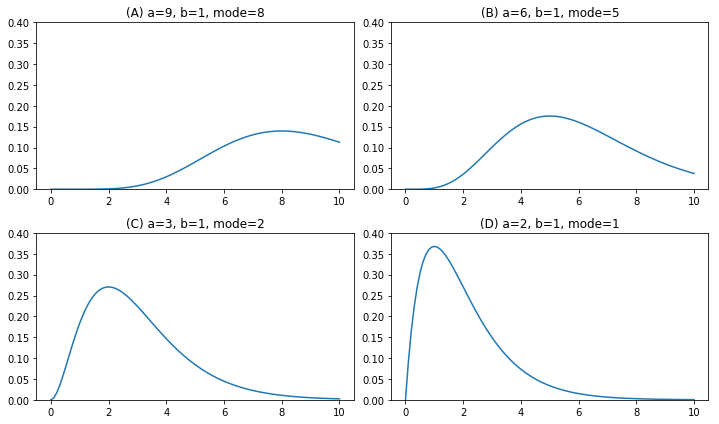

```python
# (0,10)에서 100개의 점을 찍어라.
x = np.linspace(0, 10, 100)

# 캔버스의 크기
plt.figure(figsize=(10,6))
plt.subplot(221)
plt.plot(x, sp.stats.gamma(9).pdf(x))
plt.ylim(0, 0.4)
plt.title("(A) a=9, b=1, mode=8")

plt.subplot(222)
plt.plot(x, sp.stats.gamma(6).pdf(x))
plt.ylim(0, 0.4)
plt.title("(B) a=6, b=1, mode=5")

plt.subplot(223)
plt.plot(x, sp.stats.gamma(3).pdf(x))
plt.ylim(0, 0.4)
plt.title("(C) a=3, b=1, mode=2")

plt.subplot(224)
plt.plot(x, sp.stats.gamma(2).pdf(x))
plt.ylim(0, 0.4)
plt.title("(D) a=2, b=1, mode=1")

plt.tight_layout()
plt.show()
```

위 그림이 베이지안 추정 결과라면 각각은 모수에 대해 다음과 같이 추정한 것과 같다.

- (A): 모수값이 8일 가능성이 가장 크다. (정확도 아주 낮음)
- (B): 모수값이 5일 가능성이 가장 크다. (정확도 낮음)
- (C): 모수값이 2일 가능성이 가장 크다. (정확도 높음)
- (D): 모수값이 1일 가능성이 가장 크다. (정확도 아주 높음)

**판단할 때는 x값을 봐야 한다.**

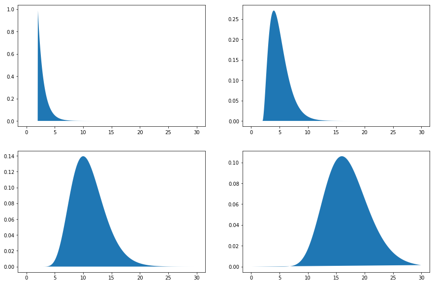

```python
plt.figure(figsize=(15,10))
xx = np.linspace(0, 30, 1000)
plt.subplot(221); plt.fill(xx, sp.stats.gamma(1, 2).pdf(xx));
plt.subplot(222); plt.fill(xx, sp.stats.gamma(3, 2).pdf(xx));
plt.subplot(223); plt.fill(xx, sp.stats.gamma(9, 2).pdf(xx));
plt.subplot(224); plt.fill(xx, sp.stats.gamma(15, 2).pdf(xx));
```

### sympy를 사용하여 감마분포 정의 출력

```python
from sympy import *
from sympy.stats import *
import sympy

init_printing()

a = Symbol("a", positive=True)
b = Symbol("b", positive=True)
x = Symbol("x")
X = sympy.stats.Gamma("X", a, b)
D = sympy.stats.density(X)(x)
D
```

$$\frac{x^{a - 1}}{\Gamma{\left(a \right)}} b^{- a} e^{- \frac{x}{b}}$$

#### 여기서 베타는 베타의 역수로 들어가 있다. 역수를 넣어도 값은 똑같다.

- (a, b) = (1, lambda) 이면 지수분포가 된다.

```python
expand_func(simplify(sympy.stats.E(X, meijerg=True)))
```

$$a b$$

```python
expand_func(simplify(sympy.stats.variance(X, meijerg=True)))
```

$$a b^{2}$$

### Beta distribution 베타 분포

> 정의

$$ \begin{eqnarray*} Beta(x; a, b) &=& \frac{1}{B(a,b)} x^{a-1}(1-x)^{b-1} \\ &=& \frac{\Gamma{(a+b)}}{\Gamma{(a)}\Gamma{(b)}} \cdot x^{a-1}(1-x)^{b-1} \\ \end{eqnarray*} $$$$ \text{단,} \; (0\leq x < 1)\text{이며} \;\;\; a, b > 0 \;\;\text{이다.} $$

> 베타 분포의 확률 밀도 함수는 0부터 1까지만의 값을 가진다. 이러한 함수를 finite support를 가진다고 한다.

$$ B(a,b) = \frac{\Gamma{(a)}\Gamma{(b)}}{\Gamma{(a+b)}} $$$$ \Gamma(\alpha) = \int_0^\infty x^{\alpha-1} e^{-x}$$

> 다른 확률 분포와 달리 자연계에 존재하는 데이터의 분포를 묘사하기 보다는 **베이지안 추정의 결과를 묘사하기위한 목적**으로 주로 사용된다.

> 베이지안 추정(Bayesian estimation)은 추정하고자 하는 모수의 값을 하나의 숫자로 나타내는 것이 아니라 **분포**로 묘사한다.

> > Bernoulli 분포의 parameter 값을 모형화하는데 사용

> 베타 분포의 pdf는 a와 b라는 두 개의 모수(parameter)를 갖는다.

> Mean: $$E[x] = \dfrac{a}{a+b}$$

a 커질수록 E(x)는 오른쪽으로 간다.

> Mode: $$\dfrac{a - 1}{a+b - 2}$$

평균에서 분모, 분자에서 각각 -1을 하면 mode값

> Variance: $$\text{Var}[x] = \dfrac{ab}{(a+b)^2(a+b+1)}$$

a, b가 커질수록 분산은 작아진다.

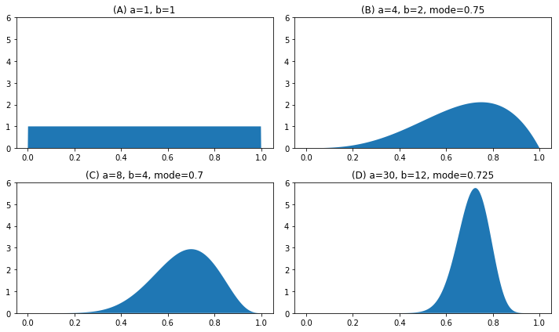

```python
# (0,1)에서 1000개의 점을 찍어라.
x = np.linspace(0, 1, 1000)

plt.figure(figsize=(10,6))

## (a,b) = (1,1)로 하면 아래 면적이 칠해지지 않음, 그래서 아래처럼 알파와 베타값을 넣음
plt.subplot(221)
plt.fill(x, sp.stats.beta(1.0001, 1.0001).pdf(x)); plt.ylim(0, 6)
plt.title("(A) a=1, b=1")

plt.subplot(222)
plt.fill(x, sp.stats.beta(4, 2).pdf(x)); plt.ylim(0, 6)
plt.title("(B) a=4, b=2, mode={}".format((4-1)/(4+2-2)))

plt.subplot(223)
plt.fill(x, sp.stats.beta(8, 4).pdf(x)); plt.ylim(0, 6)
plt.title("(C) a=8, b=4, mode={}".format((8-1)/(8+4-2)))

plt.subplot(224)
plt.fill(x, sp.stats.beta(30, 12).pdf(x)); plt.ylim(0, 6)
plt.title("(D) a=30, b=12, mode={}".format((30-1)/(30+12-2)))

plt.tight_layout()
plt.show()
```

> 위 그림이 베이지안 추정 결과라면 각각은 모수에 대해 다음과 같이 추정한 것과 같다.
> - (A): 추정할 수 없다. (정보가 없음)
> - (B): 모수값이 0.75일 가능성이 가장 크다. (정확도 낮음)
> - (C): 모수값이 0.70일 가능성이 가장 크다. (정확도 중간)
> - (D): 모수값이 0.725일 가능성이 가장 크다. (정확도 높음)

### sympy를 사용하여 베타 분포 함수를 정의

```python
from sympy import *
from sympy.stats import *
import sympy

init_printing()

# positive=True → 양수로 정의
a = Symbol("a", positive=True)
b = Symbol("b", positive=True)
x = Symbol("x")
X = sympy.stats.Beta("X", a, b)
D = sympy.stats.density(X)(x)
D
```

$$\frac{x^{a - 1}}{\beta{\left (a,b \right )}} \left(- x + 1\right)^{b - 1}$$

```python
expand_func(simplify(sympy.stats.E(X, meijerg=True)))
```

$$\frac{a}{a + b}$$

### 분포의 하이퍼 파라미터 추정

#### 구간 내의 값을 알고 있을 때

> Beta 분포 사용

#### 평균을 알고, 범위를 알고 있을 때

> 가우시안 정규 분포 사용

#### 범위가 양의 실수인 경우

> Gamma 분포 사용

#### Related Posts

> « 난수 발생과 카운팅 with NumPy probability for data-science ⑥ »